# ENS-2002 Scientific Notebook MK2 number 2

Tobias Nunn

2025-01-13

# EggNog-Mapper initial test analyses (2025-01-10 to 2025-01-19)

## Introduction

Aaron emailed me back with advice on a way to make eggNog-mapper/2.1.12 on hawk work. As i am revising for an exam i can’t spend too long on this. p.s. i think i did pretty good on the exam. This section is somewhat of a proof of concept just so i can understand and play with the base commands for eggnogmapepr and try to get it running quickly, and all the trials that entails. Hawk is still running slow, so while those jobs from the previous section are running, i figured i would like to do something extra to fill time. I wanted to see just how many samples we are going to need to pull down and process for this and get a rough time estimate for that, as well as the API stuff to pull the files down as that is by far the easy bit

## Methods

Today(the 12th) i set off 3 jobs each containing 3 accessions to hopefully get the results of the remaining 9. If there are no complications i will then be in a place where i can obtain the .fastas for the online comparison accessions and then run them through eggNog-mapper. It should be noted that i used the same list of parameters i found on the web version of hawk for this.

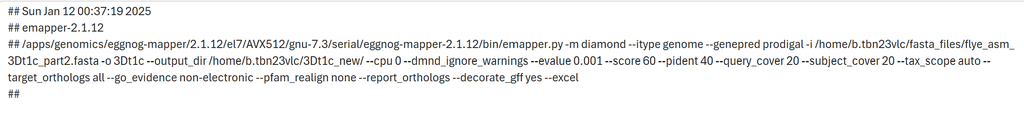

Figure 1 - Screenshot of parameters used in early eggnog runs on hawk

I had some marginal success, the second set of three finished in over 3 hours, the other 2 sets are still going strong after 8, so ill let them time out over night and see what i have, maybe they will complete, i did give them 12 hours. One of the remaining two finished just before the time limit, the other timed out on sample 1Dt100h, proving to be a difficult sample, this means i have 8 of 10, with the other missing being 1Dt1h(alphabetically next).

I then discovered the command `dbmem` which could help to speed up the process. I tested with [this file called “anothergo.sh”](https://github.com/tobiasnunn/tnunn_research/blob/a962833b3ec1b2c7420fef155b526f2b330d644c/00_scripts/anothergo.sh). The version linked to is not the file at that point, as i am doing the linking here retroactively. This was set to run over night from roughly 9 30 pm on the 12th to 3 30 am on the 13th, totalling 6 hours for 5 files, not great. I then experimented with taking out some of the arguments `--evalue 0.001 --score 60 --pident 40 --query_cover 20 --subject_cover 20`. This did not significantly increase time and likely hindered the quality of the sample, so that was a dead end. Tomorrow(14th) i will have a look at recreating run 1 with `dbmem` switched on. Around this time i also tried to run two scripts in parallel, same content but different source fastas, being another old version of “anothergo.sh” and “anothergoparallel.sh”. This was not successful as slurm scheduled them sequentially. Today(19th), i changed some criteria around so now there are 25 cpus per task, however, i believe i had already been doing this by accident in the previous runs i did. There are two files, one being the up-to-date version of “anothergo.sh” and one called [Brachyscript.sh](https://github.com/tobiasnunn/tnunn_research/blob/a962833b3ec1b2c7420fef155b526f2b330d644c/00_scripts/brachy_script.sh) which did multiple files in sequence but from the same script. I believe these were not testing any parameters and were just attempts at preliminary downloads to guage how long it might take. Speed has not picked up considerably, so i may have reached the limits of how fast i can make this and thus, it might be time to email Aaron to see what he thinks. He emailed me back with some ideas about how i could use python scripts to loop and that could make slurm do them in parallel.

I started this by making tables based along the sets of samples i am going to need off of the ncbi website. I identified 3 groups of samples: 1. all the genera in the family sphingomonadaceae / 2. all the genera in the family Microbacteriaceae / 3. all the genera containing our flye_asm samples This fits with the specification of work i was given. Being 2 analyses, 1 for comparing just our genera and another comparing genera in families we have multiple samples in. As of now i am yet to do the API call. (still the 17th) I decided to run some more tests to try cut the time down by adding some more commands to my anothergo.sh script. I was having trouble with creating the slurm scripts on hawk, it was a lot of typing complex strings, so i made another script maker to automate that, which will be much more convenient when working at scale, here

## Results

Run one had mixed results, 3 sets of 3 ran in parallel, set 1 completed in 3 and a half hours, good. set 2 took 8 and a half hours, bad, set 3 timed out, very bad. so dont have the outputs needed for 1Dt100h or 1Dt1h. Run 2 was more successful, with 5 solid looking outputs in 6 hours. Run 3 did not improve on that time despite the extra parameters being cut. As mentioned above, i managed to use `dbmem` and more optimised cpu and memory usage using the `seff` command. This helped get the average time to do a file down to roughly 27 minutes. After emailing Aaron he agreed that the list of accessions should be cut down to remove groups with low sample counts, i decided to cut at the number 30, so groups with 29 or below are cut, as seen in these tables:

### All tables

#### Family Sphingomonadaceae

Table 1 - count of genera in the family Sphingomonadaceae

accessions as found in the .tree file outputted by gtdbtk analysis done on 2024-12-24

|  | Family and Genus | Number of Accessions |
| --- | --- | --- |
| f__Sphingomonadaceae |  |  |
|  | g__Erythrobacter | 66 |
|  | g__Novosphingobium | 115 |
|  | g__Sphingobium | 77 |
|  | g__Sphingomicrobium | 38 |
|  | g__Sphingomonas | 205 |
|  | g__Sphingopyxis | 62 |
| Total | — | 563 |

This is a subset of the full list, filtered to those genera with more than 29 accessions.

#### Family Microbacteriaceae

Table 2 - count of genera in the family Microbacteriaceae

accessions as found in the .tree file outputted by gtdbtk analysis done on 2024-12-24

|  | Family and Genus | Number of Accessions |
| --- | --- | --- |
| f__Microbacteriaceae |  |  |
|  | g__Agromyces | 41 |
|  | g__Cryobacterium | 43 |
|  | g__Curtobacterium | 51 |
|  | g__Leucobacter | 43 |
|  | g__Microbacterium | 254 |
|  | g__Rhodoluna | 35 |
| Total | — | 467 |

This is a subset of the full list, filtered to those genera with more than 29 accessions.

#### Our Genera

Table 3 - count of genera from accessions produced at Bangor

accessions as found in the .tree file outputted by gtdbtk analysis done on 2024-12-24

|  | Genus | Number of Accessions |
| --- | --- | --- |
|  | g__ | 1 |
|  | g__Brachybacterium | 32 |
|  | g__Brevibacterium | 43 |
|  | g__Microbacterium | 254 |
|  | g__Pantoea | 52 |
|  | g__Sphingomonas | 205 |
| Total | — | 587 |

Right, as of 11:12 today (17th) i have managed to do a successful run using this file that gave me the output in a nice 25 minutes. I added some extra fields that i saw both on the online eggnogmapper and from a stack-overflow from someone doing a similar thing and something worked. using this new number, 1,820 x 0.4167 = 758.4 hours = 31.6 days so even now i’m down to just over a month, good stuff. This one used 10 cpus, the online one used 20, but i didnt want to overdo it with hawk, now im thinking can i get that number to half again by doubling the cpus?

As of the 24th Aaron agrees with my assessment to cut down on the number of samples, this leaves me with 1158 samples to run, at an average of 27 minutes, this would take 21.7 days, however, this would speed up dramatically if i can get his loops working so parallel stuff can happen.

## Conclusion

It could have been overcrowding on hawk, however it appears that running multiple sets in parallel adversely affects the result, however, i have not tested this with `dbmem` on. The large problem is the volume of samples required, the desired output is 3 heatmaps comparing KO pathways: - Comparing genera inside sphingomonadaceae - Comparing genera inside Microbacteriaceae - Comparing the genera containing just our samples. This number of hours is not one i can logistically work with, maybe Aaron would be fine with me taking that time, but i feel i can do it faster. I am still working on improving the script to cut down on time taken, but hawk is being a pain in that regard, i have also starting thinking of alternatives or ways to cut down the list. My front-running idea is to take samples from only genera with more than 10, or 30 or some other arbitrary high number of samples. This would cut out all groups with only 1-4 accessions in them which i dont think are useful to this analysis anyway as an average cannot be calculated, it would also make the heatmaps much more legible, so i might run the numbers on what cutting down the sample size would look like. It may however, be better to group all those small genera into an “other” column to make the dataset as big as possible, but that doesnt solve my predicament. The total time continues to shrink, with the filter in place and hopefully with the loops working it could take less than 10 days

📌 ?: TODO: [eggnog-mapper on hawk is slow, possibly too slow to scale to where we need it to be. alternatives: > what scale are we looking at - 1693 samples for the family comparison > could limit to genera with more than 30 samples > screenscrape-method > enlist more manpower to do online(if we have to do on web)]

📌 ?: TODO: trees and formatting (never did gtdb repeat because need download all the metadata to make it nice and sparkly)

# A cautionary tale (2025-01-24 11:48)

So for the past 2 weeks while i was doing exams i decided i didnt want to fully stop this project, but i didnt have enough time to do stuff and properly fill the notebook, so i decided to leave myself placeholders in multiple square brackets to make it obvious when i came back later, i can’t replicate this here. For some unknown reason doing too many square brackets breaks the visual editor and busts the ability to knit. Anyway, because of that i haveant been able to knit all this time and have just lost the whole morning to trying to fix this, all over some square brackets… the shame i feel from this is immeasurable. This really does prove that there is **always** time for proper note taking.

📌 ?: TODO: API call for JSONS, fastas

# Prototype Heatmap Creation Run, end-to-end: step 1 2025-01-24 to 2025-01-26

## introduction

Ok, i am done with the eggnog testing, i am in a place now where i am happy to begin actually doing stuff with this. I figured that i should start with the less intensive analysis, being the genera comparison of just the ones our samples are in, seen in Table 3: Our Genera. This is so that i don’t have to think about automation to the same degree yet, thus, i can create the pipeline in a more crude way and add “fancy code stuff” to make it better later so i’m not wondering whats causing problems. Even then, i am still going to start smaller, taking only 10 from each genus so that i can create a prototype of sorts, hopefully to show Aaron when i am back in Bangor. Here is my plan for this section:

1. Download the metadata for the chosen genera, this is going to use the dataset_report API for the NCBI website. These will serve multiple purposes, for example they will tell me which samples have a high quality metric, they will also help with the generation of trees from gtdb-tk de_novo_wf done in Notebook 1, but not output because of this exact reason.
2. Choose 10 accessions per genus to use in my prototype pipeline. All groups will total 10 samples, our own Bangor-made accession will be included in this number, excluding 1Dt100h, as gtdb-tk could not classify it into a family.
3. Download the genomic .fasta files for all of these. This will use the [Download API](https://www.ncbi.nlm.nih.gov/datasets/docs/v2/api/rest-api/#get-/genome/accession/-accessions-/download) to pull them from the NCBI website.
4. Annotate all those fastas using eggNog-mapper on hawk.
5. create the file(s) that turn the annotation file into a heatmap

## Results

The API call itself took around 2 minutes to get 587 samples, very fast, but also just slow enough to avoid the limit NCBI imposes on download volume. The ANI stuff in the JSON files was very intriguing for me, i decided i wanted to output a summary of the JSON files by their ANI statuses:

### All tables

#### JSON ANI analysis

Table 4 - Analysis of Taxonomy Check Status

as a part of analysis for Average Nuleotide Identity(ANI)

| Taxonomy Check Status | Count | Visual |
| --- | --- | --- |
| OK | 445 |  |
| Inconclusive | 100 |  |
| Absent | 33 |  |
| Failed | 9 |  |

Source: API call to the NCBI website done on 2025-01-24

#### ANI match status analysis

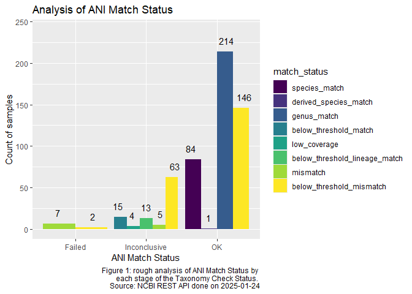

#### Completeness histogram

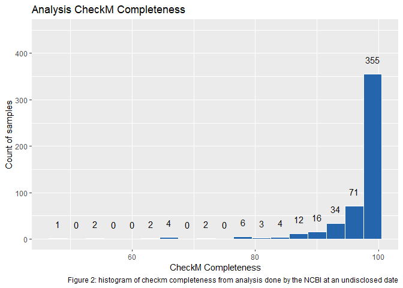

#### Contamination histogram

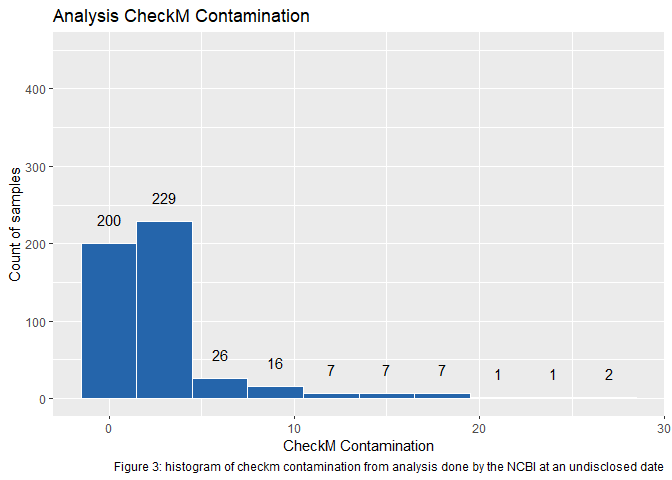

The first file, “NCBImetadatacollector.R” creates a directory with all of the JSON files in it [here](https://github.com/tobiasnunn/tnunn_research/tree/be8100b850eea50a9e3132806623b4f1d1d08956/02_middle-analysis_outputs/ncbi_stuff/json) and a file containing the table derived from gtdb-tk, [here](https://github.com/tobiasnunn/tnunn_research/blob/be8100b850eea50a9e3132806623b4f1d1d08956/02_middle-analysis_outputs/analysis_tables/genera_analysis.tsv). The second file, “jsondataexplorationprep.R” combines these into [genera_analysis_combined.R](https://github.com/tobiasnunn/tnunn_research/blob/be8100b850eea50a9e3132806623b4f1d1d08956/02_middle-analysis_outputs/analysis_tables/genera_analysis_combined.tsv). I used the package “jsonlite” to do this. This does not exist as a code file, as i did all the coding inside this document. The function `hoist()` from the package tidyr was also very helpful in drawing out the lower levels of the JSON files.

I had many attempts at visualising all of the interesting columns but possibly from messy data, possibly from a lack of understanding the fields i did not make much progress on that. When trying to display the information from the “match_status” column i ran into issues relating to obscure scientific terms. One point of confusion was the reference genomes, put in the “OK” taxonomy_check_status having a “below_threshold_mismatch” in the former column. This is the lowest, or “worst” on the hierarchy listed [here.](https://www.ncbi.nlm.nih.gov/datasets/docs/v2/policies-annotation/quality/ani/) This field was especially cryptic, with the hierarchy not working as this page said it should.

## Conclusion

I do not believe the graphs from this section show anything too spectacular, however it was good practice at graphing and the main purpose, being downloading the JSON files so i can make an informed choice on which accessions will go in my prototype heatmap was a success. I will be honest, i spent a little too much effort on these graphs, there were many challanges with doing these things, but i learnt a lot from that struggle. The next section should however be more interesting.

📌 ?: TODO: have a look back at checkm and ANI(if it exists) analysis for the local samples to add to the combi table in “jsonataexplorationprep.R” next graphs up are going to be more simple ones like the one for ANI, and then i also had the idea of doing a sort of “megagraph” for completeness against contamination, where the colour is the “refseq category” as for some reason, the accession with the highest contamination is a reference genome, I can also modify the column to include “bangor” as the category for ours so I know where they place.

# Prototype Heatmap Creation Run, end-to-end: steps 2 + 3 2025-01-26 to 2025-01-27

## Introduction

In part 1, i generated the metadata table that will help me choose “high quality” samples(and maybe go on to make the phylogenetic trees from gtdb-tk a bit more flashy later). This section will focus on specifying a set of samples so that each “group” (a subset of samples for each relevent genus) will total 10 samples, for 50 total (4 samples are *Sphingomonas,* 2 are *Microbacterium,* there are 1 each for *Brachybacterium, Brevibacterium* and *Pantoea*). This only totals 9 samples, this is because I am excluding 1Dt100h due to it not being given a genus by gtdb-tk de_novo_wf. This means i need to select 41 more samples to download the .fasta file for and copy to hawk.

## Methods

This process will use another command in the NCBI REST API library called -accessions-/download. This will utilise the combined table made in step 1 to filter to 41 online reference samples of good quality to make the list i will pass to the API call. My list will not include reference samples because I do not find that as “organic”. On the morning, of the 27th at 8:40 i ran the NCBI REST API to download the subset of the fastas, using the same document i started yesterday, NCBIfastacollectorprototype.R. The code therein place the .fastas in a directory in 02_middle-analysis_outputs/ncbi_stuff. However, this will not show on github because there are many and fasta files are very large and i have a limited space allowance in the repo. I then modified this file to include another for loop to unzip the files and give me the .fastas, [here.](https://github.com/tobiasnunn/tnunn_research/blob/2827ddaa51c73370b0d1b4a7ca847dfc634acff6/00_scripts/NCBIfastacollectorprototype.R)

## Results

As mentioned above: the directory containing the .fastas is part of the .gitignore, so there are no visible results, but trust me, they are there.

## Conclusion

Non Applicable, this is just a quick intermediary

# Prototype Heatmap Creation Run, end-to-end: step 4 2025-01-27 to 2025-01-28

## Introduction

I have the 41 fastas, the job of uploading them to hawk was easy enough. Now i need to think automation, i could manually input all these files into a slurm script, but that is not very fun, and more practically, very error prone. This means i need to think how i might automate a script to sort of iterate over a directory of files.

## Methods

From my testing earlier this month, i have [this bash script](https://github.com/tobiasnunn/tnunn_research/blob/2827ddaa51c73370b0d1b4a7ca847dfc634acff6/00_scripts/anothergo_morecpu.sh). It is the best i have so far, but it is still manual. Noteable improvements i made were the mailing parameters so i can see when a job is done from my phone, and some general messing about with `seff` to optimise things like cpus and memory. I decided to use this as a template to make [this script](https://github.com/tobiasnunn/tnunn_research/blob/2827ddaa51c73370b0d1b4a7ca847dfc634acff6/00_scripts/prototypebatch1.sh). This will run 3 accessions, alphabetically descending so i can keep track. I originally was going to run three of these, but trying to manually copy + paste in all those complex alphanumeric strings was difficult. Thus, proving the need for automation. This file will run hopefully while i’m in lectures this afternoon, and i can then work on making the script better (hopefully without breaking it), after that. There was no real reason to do it this way, i just wanted something to be happening while i was in lectures as i had the .fastas anyway. In the evening, i attempted to begin using parameters to automate some of the naming to speed up (and make less error prone) the process. Using help from an email from Aaron.

Ok, while those are doing, i need to think about how i am going to get the .xlsx files off of hawk once they are done. This lead me to generate eggnog_annotation_getter.sh. An easy-peasy little file that pulls out all the .xlsx files and slaps them into a directory. Once more are done, i will manually pull them off of hawk, maybe i should zip them first? we’ll see. Anyway, i might as well get to work on the pipeline to turn these into a heatmap so it is ready for when all 41 have downloaded.

## Results

As mentioned above: the directory containing the .fastas is part of the .gitignore, so there are no visible results, but trust me, they are there. I am guessing the same will go for the directory containing the xlsx files, but they are a fair ways smaller so maybe for the prototype stage they will be alright.

## Conclusion

Non Applicable, this is just a quick intermediary

# Prototype Heatmap Creation Run, end-to-end: step 5 2025-01-27 to 2025-01-29 💎🦍🗿

## Introduction

So, the 41 accessions are going through eggnog, good. This is however going to take time, under or around 20 hours total if they do not do in parallel, which i do not think is likely. So, i might as well get to work creating the file(s) that go into turning the .xlsx files from hawk into a metadata file into a heatmap. I want to get this in one file for simplicity, but two might be necessary / more optimal in ways i don’t quite understand yet.

## Methods

After pulling down the annotations that had been run by 20:37 on the 28th, 20 total with the local samples, i started by making the metadata file needed to begin the pipeline to the heatmap. This involved two columns, mag_id and bac_taxon. I used the file metadata_maker.R to do this, very simple, brings in files i already had, combines them and cuts out excess so what is output is just the file as per specifications of the example Aaron gave me months ago when i did the fly stuff(not relevant to this project). This output i then feed into my KEGG_pipeline_pt1.R file to turn into the intermediary. I am using two files for this part, because i realised the reason Aaron did two files was that it would be heavily inconvenient having to do all the stuff in pt1 every time you wanted to run pt2, so it is much simpler to save the outputs to a file that can easily be read in as much as you want. Progress is kind of now halted until all 50 are completed. Right, overnight between the 28th and the 29th (about 2pm to 6:30am) all 41 ran on hawk, some of them even went in parallel, i suppose that in the night there is less burden on hawk so it is more availiable to do two at once, all but one of these were successful, so now, i have to figure out which accession i don’t have so i can run that one again. i have downloaded the 40 other files to my landing pad so they can both go through the pipeline. However, i need the extra one to generate output without changing the list. This leads to the importance of inputting error handling, i still do not know why it messed up the first time ((occasionally it just happens) but after that it kept crashing because files already existed, so i added the `--override` command to override any existing files, so hopefully this run should be the last and i will have my prototype dataset by the end of today.

I should mention how useful the R packages tidyverse and dplyr have been in all of these processes. One step of note is that oddly i found that sometimes, eggnogmapper would output multiple KO pathways in the same cell (i.e. “ko:KO1234” vs “ko:KO1234,ko:KO4321,ko:KO3241”). I am unsure why it does this, maybe it can’t determine which of the three is present. Anyway, i decided to cut the list to seperate and keep all three as separate arguments, because why not, it may be that these should have been left in the same cell, but onward i go. Another issue i then ran into was `enrichko()` when i first tried to run a KO value through it, it crashed reporting

“–> No gene can be mapped….

–> Expected input gene ID: K13952,K00128,K08074,K01837,K00175,K02777

–> return NULL…”

I tried another one and it gave a result, so is it possible enrichko just does not know about some pathways? Doing a check on the KEGG website i found that the ones returning NULL do not have a map id, not sure what this means, but i think it is alright that they are being excluded, because i am looking for map ids. With that, my file KEGG_pipeline_pt1.R is done, i have the pivot table with the genera and map ids. Now i just have to turn those into heatmaps. Not too long later, i had part 2 done, KEGG_pipeline_pt2.R. This is a simple little file that reads in the output from 1, turns all the columns into proportions, pivots and other clever stuff until i have the thing to heatmap, then gives multiple possible aesthetic choices, very good.

## Results

I don’t think i can infer anything from the prototype heatmap, there are many map values, but i should wait until the whole dataset is done before just saying “these are the map values of interest”. Still, as a prototype it serves as perfect proof that I can scale up. I am going for dinner now, but i’ll try remember to put the sample heatmaps here after, tomorrow morning at the latest.

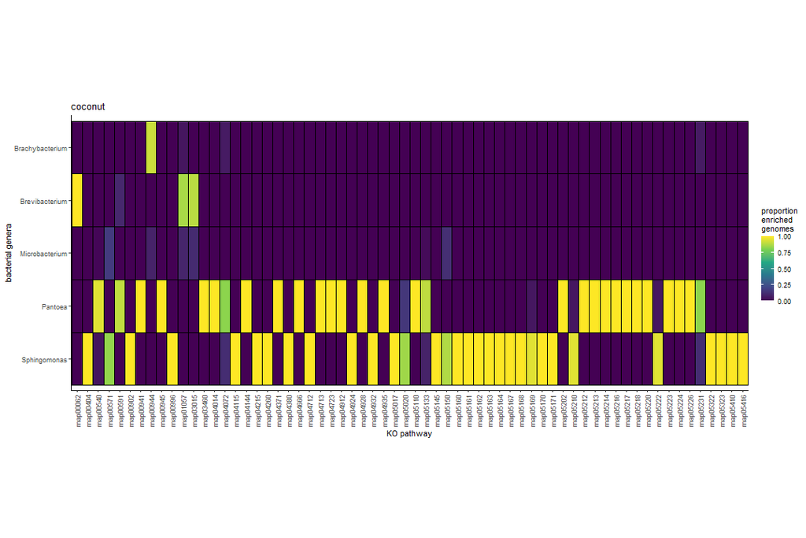

Figure 4 - Prototype Heatmap aesthetic style 1

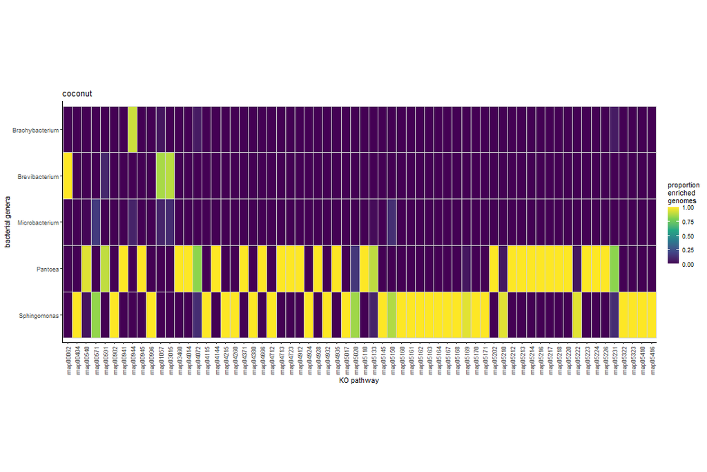

Figure 5 - Prototype Heatmap aesthetic style 2

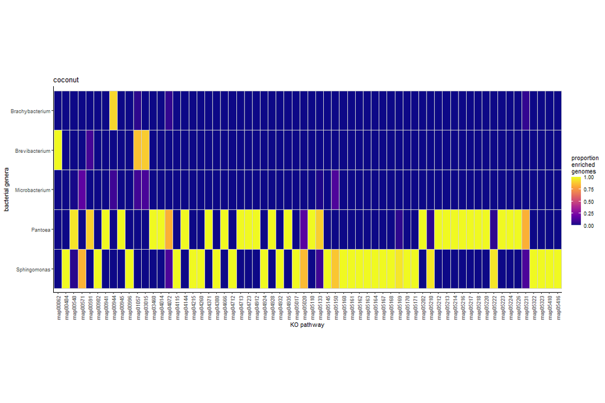

Figure 6 - Prototype Heatmap aesthetic style 3